# Análisis diferencias expresión

Sara Sentre Domingo

1/12/2021

# 1 Materiales y métodos

En este análisis de RNA-Seq nos encontramos frente a un estudio que consta de 9 muestras que se dividen en tres grupos dependiendo de si son ovejas sin patología respiratoria, si están infectadas con el lentivirus causante de Maedi-Visna y si además se han infectado con *scrapie*, cada grupo está compuesto por tres muestras.

Para poder llevar a cabo el análisis de los datos de RNA-Seq generados en este estudio vamos a utilizar el software estadístico *R*, en concreto su interfaz *R-Studio*, y varios paquetes contenidos en el proyecto *Bioconductor*. En concreto los paquetes que hemos tenido que usar han sido los siguientes:

```r
library("edgeR")
library("limma")
library("Glimma")
library("gplots")
library(AnnotationHub)
library(AnnotationDbi)
library("RColorBrewer")
library("GO.db")
```

# 2 Resultados

## 2.1 Obtención y lectura de los datos

Lo primero que tenemos que hacer para poder empezar a analizar los datos de este ensayo es crear el objeto *seqdata* que contiene información sobre los genes y el objeto *sampleinfo* que contiene la información básica de las muestras.

Para crear *seqdata* tenemos que organizar la información que se obtiene de la tabla de counts generada por STAR. En esta tabla tenemos 4 columnas: en la primera está el ID del gen, en la segunda los *counts* si el análisis se hubiera realizado sin tener en cuenta el sentido de las hebras del material genético, en la tercera los *counts* de primer sentido de lectura de las hebras y en la cuarta los *counts* del segundo sentido de lectura. Como en nuestro caso el análisis de RNA-seq sí que tuvo en cuenta los sentidos de lectura vamos a utilizar los datos de *counts* de la tercera y cuarta columna y los vamos a analizar de forma independiente.

Todos los procesos que se van a hacer con el conjunto de datos correspondiente a un sentido de lectura se van a replicar con el otro sentido de lectura, va a ser un análisis en paralelo.

Primero vamos a crear *seqdata1* que va a tener la información relativa al primer sentido de lectura y luego vamos a crear *seqdata2* que tendrá la información del otro sentido de lectura.

```r
C2data=read.table("C2_ReadsPerGene.out.tab", header=TRUE, sep="\t")
C3data=read.table("C3_ReadsPerGene.out.tab", header=TRUE, sep="\t")
C5data=read.table("C5_ReadsPerGene.out.tab", header=TRUE, sep="\t")
M1data=read.table("M1_ReadsPerGene.out.tab", header=TRUE, sep="\t")
M2data=read.table("M2_ReadsPerGene.out.tab", header=TRUE, sep="\t")
M4data=read.table("M4_ReadsPerGene.out.tab", header=TRUE, sep="\t")
MS1data=read.table("MS1_ReadsPerGene.out.tab", header=TRUE, sep="\t")
MS2data=read.table("MS2_ReadsPerGene.out.tab", header=TRUE, sep="\t")
MS3data=read.table("MS3_ReadsPerGene.out.tab", header=TRUE, sep="\t")

sampleinfo=read.table("sampleinfo.txt",header=TRUE, sep="\t")


seqdata1=C2data[, c(1,3)]
names(seqdata1)[names(seqdata1)=="C2_strand1"]="C2"
seqdata1$C3=C3data$C3_strand1
seqdata1$C5=C5data$C5_strand1
seqdata1$M1=M1data$M1_strand1
seqdata1$M2=M2data$M2_strand1
seqdata1$M4=M4data$M4_strand1
seqdata1$MS1=MS1data$MS1_strand1
seqdata1$MS2=MS2data$MS2_strand1
seqdata1$MS3=MS3data$MS3_strand1
head(seqdata1)
```

```
          gene C2  C3 C5  M1  M2  M4 MS1 MS2 MS3
1 LOC114112203  0   0  1   2  21  11   0  17  39
2 LOC114110836  0   0 24   7   0  46   1   0  21
3 LOC114113923  0 264  0   4 154 142   0  81   0
4 LOC114112459  0  39  0   0  27   0   7   3   0
5      FAM240C  0   0  0   0   0  18   0   0   0
6        PDCD1 12   0  0 606 515 752 213 438  62
```

```r
dim(seqdata1)
```

```
[1] 30186    10
```

```r
seqdata2=C2data[, c(1,4)]
names(seqdata2)[names(seqdata2)=="C2_strand2"]="C2"
seqdata2$C3=C3data$C3_strand2
seqdata2$C5=C5data$C5_strand2
seqdata2$M1=M1data$M1_strand2
seqdata2$M2=M2data$M2_strand2
seqdata2$M4=M4data$M4_strand2
seqdata2$MS1=MS1data$MS1_strand2
seqdata2$MS2=MS2data$MS2_strand2
seqdata2$MS3=MS3data$MS3_strand2
head(seqdata2)
```

```
          gene C2  C3 C5  M1  M2  M4 MS1 MS2 MS3
1 LOC114112203  0   0  0   2   7  15   1  21  46
2 LOC114110836  0   0  0   9   0  34   0   0  16
3 LOC114113923  0 143  0   0 128 157  36  94   0
4 LOC114112459  0  34  0   0  35   0  42   0   0
5      FAM240C  0   0  0   0   0   1   0   0   0
6        PDCD1  0   0  0 617 528 908 183 425  78
```

```r
dim(seqdata2)
```

```
[1] 30186    10
```

A continuación tenemos que reformatear los datos y crear un nuevo objeto que contenga solo el *counting* y los identificadores de los genes. Este objeto se va a llamar *countdata1* y *countdata2* respectivamente.

```r
countdata1=seqdata1[,-(1)]
rownames(countdata1)=seqdata1[,1]
colnames(countdata1)
```

```
[1] "C2"  "C3"  "C5"  "M1"  "M2"  "M4"  "MS1" "MS2" "MS3"
```

```r
head(countdata1)
```

```
             C2  C3 C5  M1  M2  M4 MS1 MS2 MS3
LOC114112203  0   0  1   2  21  11   0  17  39
LOC114110836  0   0 24   7   0  46   1   0  21
LOC114113923  0 264  0   4 154 142   0  81   0
LOC114112459  0  39  0   0  27   0   7   3   0
FAM240C       0   0  0   0   0  18   0   0   0
PDCD1        12   0  0 606 515 752 213 438  62
```

```r
table(colnames(countdata1)==sampleinfo$sample.id)
```

```
TRUE
   9
```

```r
countdata2=seqdata2[,-(1)]
rownames(countdata2)=seqdata2[,1]
colnames(countdata2)
```

```
[1] "C2"  "C3"  "C5"  "M1"  "M2"  "M4"  "MS1" "MS2" "MS3"
```

```r
head(countdata2)
```

```
             C2  C3 C5  M1  M2  M4 MS1 MS2 MS3
LOC114112203  0   0  0   2   7  15   1  21  46
LOC114110836  0   0  0   9   0  34   0   0  16
LOC114113923  0 143  0   0 128 157  36  94   0
LOC114112459  0  34  0   0  35   0  42   0   0
FAM240C       0   0  0   0   0   1   0   0   0
PDCD1         0   0  0 617 528 908 183 425  78
```

```r
table(colnames(countdata2)==sampleinfo$sample.id)
```

```
TRUE
   9
```

Lo siguiente que vamos a hacer es filtrar y eliminar los genes con recuentos muy bajos para eliminar posible ruido del análisis posterior. Este filtrado lo vamos a hacer teniendo en cuenta que vamos a retener genes que se expresen en un conteo por millón (CPM) por encima de 0.5 en dos muestras como mínimo. Vamos a utilizar los siguientes comandos para crear los valores CPM:

```r
myCPM1=cpm(countdata1)
head(myCPM1)
```

```
                   C2       C3        C5         M1        M2         M4
LOC114112203  0.00000  0.00000  0.594383  0.1072760  1.091457  0.6248275
LOC114110836  0.00000  0.00000 14.265191  0.3754659  0.000000  2.6129148
LOC114113923  0.00000 26.92143  0.000000  0.2145520  8.004021  8.0659545
LOC114112459  0.00000  3.97703  0.000000  0.0000000  1.403302  0.0000000
FAM240C       0.00000  0.00000  0.000000  0.0000000  0.000000  1.0224449
PDCD1        12.58139  0.00000  0.000000 32.5046228 26.766694 42.7154774
                    MS1        MS2       MS3
LOC114112203  0.0000000  1.4806499 17.157005
LOC114110836  0.1183640  0.0000000  9.238387
LOC114113923  0.0000000  7.0548611  0.000000
LOC114112459  0.8285478  0.2612912  0.000000
FAM240C       0.0000000  0.0000000  0.000000
PDCD1        25.2115253 38.1485083 27.275239
```

```r
myCPM2=cpm(countdata2)
head(myCPM2)
```

```
             C2        C3 C5         M1         M2          M4        MS1
LOC114112203  0  0.000000  0  0.1124271  0.3726578  0.86994229  0.1201249
LOC114110836  0  0.000000  0  0.5059218  0.0000000  1.97186920  0.0000000
LOC114113923  0 15.446653  0  0.0000000  6.8143137  9.10539600  4.3244978
LOC114112459  0  3.672631  0  0.0000000  1.8632889  0.00000000  5.0452475
FAM240C       0  0.000000  0  0.0000000  0.0000000  0.05799615  0.0000000
PDCD1         0  0.000000  0 34.6837511 28.1090439 52.66050682 21.9828639
                   MS2       MS3
LOC114112203  1.882942 20.885225
LOC114110836  0.000000  7.264426
LOC114113923  8.428408  0.000000
LOC114112459  0.000000  0.000000
FAM240C       0.000000  0.000000
PDCD1        38.107166 35.414077
```

Una vez que hemos creado este archivo pasamos a filtrar los genes con la condición comentada anteriormente y quedarnos con los que nos interesan.

```r
thresh1=myCPM1 > 0.5
head(thresh1)
```

```
                C2    C3    C5    M1    M2    M4   MS1   MS2   MS3
LOC114112203 FALSE FALSE  TRUE FALSE  TRUE  TRUE FALSE  TRUE  TRUE
LOC114110836 FALSE FALSE  TRUE FALSE FALSE  TRUE FALSE FALSE  TRUE
LOC114113923 FALSE  TRUE FALSE FALSE  TRUE  TRUE FALSE  TRUE FALSE
LOC114112459 FALSE  TRUE FALSE FALSE  TRUE FALSE  TRUE FALSE FALSE
FAM240C      FALSE FALSE FALSE FALSE FALSE  TRUE FALSE FALSE FALSE
PDCD1         TRUE FALSE FALSE  TRUE  TRUE  TRUE  TRUE  TRUE  TRUE
```

```r
keep1=rowSums(thresh1) >= 2
counts.keep1=countdata1[keep1,]
summary(keep1)
```

```
   Mode   FALSE    TRUE
logical   10200   19986
```

```r
dim(counts.keep1)
```

```
[1] 19986     9
```

```r
thresh2=myCPM2 > 0.5
head(thresh2)
```

```
                C2    C3    C5    M1    M2    M4   MS1   MS2   MS3
LOC114112203 FALSE FALSE FALSE FALSE FALSE  TRUE FALSE  TRUE  TRUE
LOC114110836 FALSE FALSE FALSE  TRUE FALSE  TRUE FALSE FALSE  TRUE
LOC114113923 FALSE  TRUE FALSE FALSE  TRUE  TRUE  TRUE  TRUE FALSE
LOC114112459 FALSE  TRUE FALSE FALSE  TRUE FALSE  TRUE FALSE FALSE
FAM240C      FALSE FALSE FALSE FALSE FALSE FALSE FALSE FALSE FALSE
PDCD1        FALSE FALSE FALSE  TRUE  TRUE  TRUE  TRUE  TRUE  TRUE
```

```r
keep2=rowSums(thresh2) >= 2
counts.keep2=countdata2[keep2,]
summary(keep2)
```

```
   Mode   FALSE    TRUE
logical   10140   20046
```

```r
dim(counts.keep2)
```

```
[1] 20046     9
```

Tras todo este filtrado y selección vemos que el número de genes con el que vamos a trabajar ahora se ha reducido bastante en comparación con el número de genes con el que hemos empezado el análisis.

Lo siguiente que tenemos que hacer es crear el objeto *DGEList* que necesita *edgeR* para almacenar los datos de recuento:

```r
y1=DGEList(counts.keep1)
y1
```

```
An object of class "DGEList"
$counts
             C2  C3 C5  M1  M2  M4 MS1 MS2 MS3
LOC114112203  0   0  1   2  21  11   0  17  39
LOC114110836  0   0 24   7   0  46   1   0  21
LOC114113923  0 264  0   4 154 142   0  81   0
LOC114112459  0  39  0   0  27   0   7   3   0
PDCD1        12   0  0 606 515 752 213 438  62
19981 more rows ...

$samples
    group lib.size norm.factors
C2      1   948137            1
C3      1  9801400            1
C5      1  1674881            1
M1      1 18634924            1
M2      1 19230896            1
M4      1 17596225            1
MS1     1  8443455            1
MS2     1 11473509            1
MS3     1  2267329            1
```

```r
names(y1)
```

```
[1] "counts"  "samples"
```

```r
y1$samples
```

```
    group lib.size norm.factors
C2      1   948137            1
C3      1  9801400            1
C5      1  1674881            1
M1      1 18634924            1
M2      1 19230896            1
M4      1 17596225            1
MS1     1  8443455            1
MS2     1 11473509            1
MS3     1  2267329            1
```

```r
y2=DGEList(counts.keep2)
y2
```

```
An object of class "DGEList"
$counts
             C2  C3 C5  M1  M2  M4 MS1 MS2 MS3
LOC114112203  0   0  0   2   7  15   1  21  46
LOC114110836  0   0  0   9   0  34   0   0  16
LOC114113923  0 143  0   0 128 157  36  94   0
LOC114112459  0  34  0   0  35   0  42   0   0
PDCD1         0   0  0 617 528 908 183 425  78
20041 more rows ...

$samples
    group lib.size norm.factors
C2      1   907390            1
C3      1  9253200            1
C5      1  1587350            1
M1      1 17780528            1
M2      1 18774995            1
M4      1 17233880            1
MS1     1  8319181            1
MS2     1 11145077            1
MS3     1  2197458            1
```

```r
names(y2)
```

```
[1] "counts"  "samples"
```

```r
y2$samples
```

```
    group lib.size norm.factors
C2      1   907390            1
C3      1  9253200            1
C5      1  1587350            1
M1      1 17780528            1
M2      1 18774995            1
M4      1 17233880            1
MS1     1  8319181            1
MS2     1 11145077            1
MS3     1  2197458            1
```

## 2.2 Control de calidad

Una vez que hemos hecho todo el tratamiento inicial de los datos pasamos al control de calidad de los mismos. Lo primero que vamos a hacer es crear un gráfico de barras que nos permita observar si hay diferencias importantes entre las muestras del estudio.

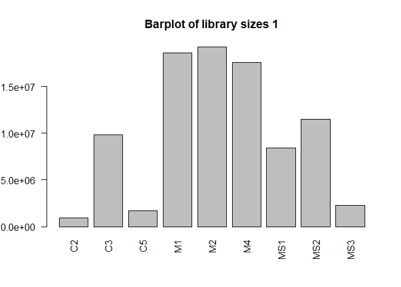

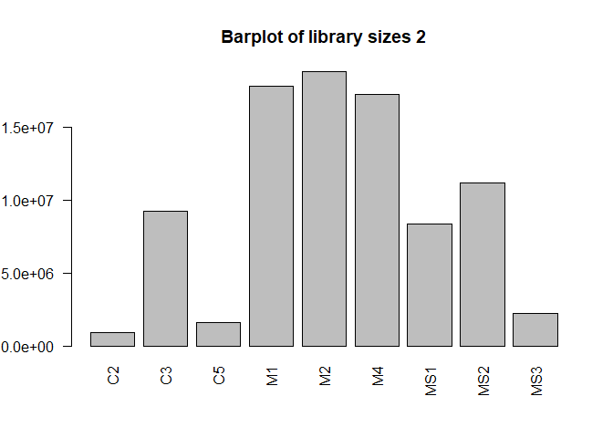

Como los datos de recuento no se distribuyen siguiendo una distribución normal si queremos examinar esos datos tenemos que usar una escala logarítmica $log2$.

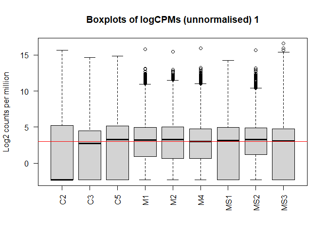

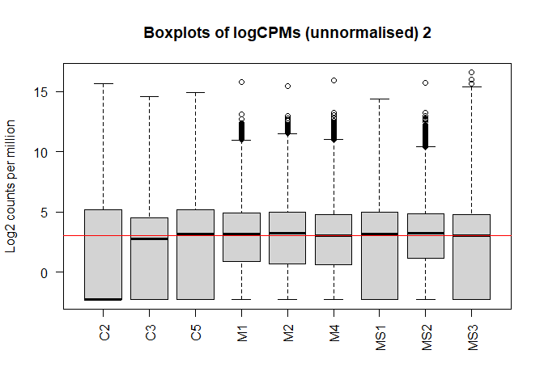

Gracias a este gráfico vemos que las distribuciones del *countig* data son bastante variadas y diferentes entre sí, aunque se puede apreciar que las de las muestras con Maedi-Visna aparentemente son más similares entre sí. Además, la mayoría de las muestras (excepto C2) coinciden bastante con la línea roja que hemos dibujado para marcar la mediana del $logCPM$.

El siguiente análisis de control de calidad que podemos hacer es un gráfico MDS que nos va a permitir visualizar la variabilidad de los datos ya que idealmente lo que tendríamos que encontrarnos sería que las causas principales de variación son los grupos de estudio y no algún otro factor.

```r
par(mfrow=c(1,2))
col.cell=c("darkorchid3","cadetblue2","blue")[sampleinfo$group]
data.frame(sampleinfo$group,col.cell)
```

```
  sampleinfo.group    col.cell
1                C darkorchid3
2                C darkorchid3
3                C darkorchid3
4               MV        blue
5               MV        blue
6               MV        blue
7               MS  cadetblue2
8               MS  cadetblue2
9               MS  cadetblue2
```

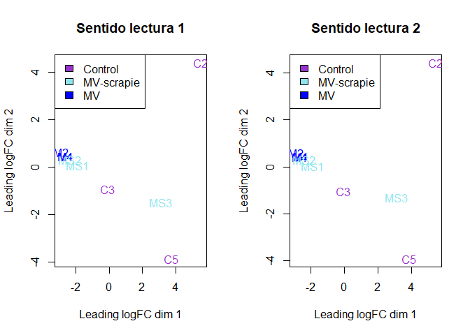

```r
plotMDS(y1,col=col.cell,main="Sentido lectura 1")
legend("topleft",fill=c("darkorchid3","cadetblue2","blue"),legend=c("Control", "MV-scrapie", "MV"))

plotMDS(y2,col=col.cell, main="Sentido lectura 2")
legend("topleft",fill=c("darkorchid3","cadetblue2","blue"),legend=c("Control", "MV-scrapie", "MV"))
```

Como último paso del control de calidad de los datos vamos a realizar un gráfico *heatmap* con clusterización que utiliza una matriz de distancias euclídeas con los datos del logCPM.

```r
var_genes=apply(logcounts1, 1, var)
select_var=names(sort(var_genes, decreasing=TRUE))[1:500]
highly_variable_lcpm=logcounts1[select_var,]
dim(highly_variable_lcpm)
```

```
[1] 500   9
```

```r
head(highly_variable_lcpm)
```

```
                    C2         C3        C5       M1       M2        M4
LOC101120093 -2.323062 -2.3230624 -2.323062 6.858696 7.922877  7.754026
LOC101120392 -2.323062 -2.3230624 -2.323062 7.481683 8.452502  8.444834
LOC101119685 -2.323062 -0.7179811 -2.323062 8.274349 8.225958  8.303030
LOC114108618 -2.323062  7.9066586  6.902209 2.647021 9.546205 10.738244
FABP5        -2.323062  6.1704516 -2.323062 6.542215 7.557950  7.990321
LGALS1       -2.323062  5.9946287 -2.323062 7.875039 8.919806  8.401847
                    MS1      MS2       MS3
LOC101120093  6.4933258 6.785020 -2.323062
LOC101120392  6.0938116 7.664202  4.612202
LOC101119685  7.8295730 7.990179  5.790010
LOC114108618 -0.3363963 2.369552  9.589218
FABP5         6.4233809 6.177241 -2.323062
LGALS1        8.2800958 8.146562  3.747523
```

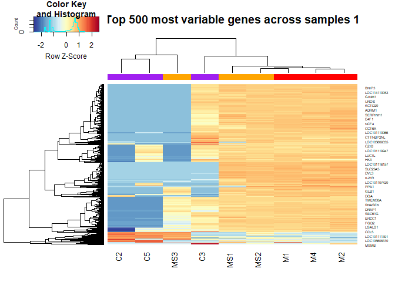

```r
mypalette=brewer.pal(11,"RdYlBu")
morecols=colorRampPalette(mypalette)
col.cell=c("purple","orange","red")[sampleinfo$group]
heatmap.2(highly_variable_lcpm,col=rev(morecols(50)),trace="none", main="Top 500 most variable genes across samples 1",ColSideColors=col.cell,scale="row")
```

```r
var_genes=apply(logcounts2, 1, var)
select_var=names(sort(var_genes, decreasing=TRUE))[1:500]
highly_variable_lcpm=logcounts2[select_var,]
dim(highly_variable_lcpm)
```

```
[1] 500   9
```

```r
head(highly_variable_lcpm)
```

```
                    C2        C3        C5       M1       M2       M4      MS1
ARHGDIB      -2.276316  6.114025 -2.276316 7.212275 8.028083 7.998915 7.881459
LOC101119685 -2.276316 -0.914205 -2.276316 8.221364 8.178882 8.257932 7.957381
LOC101120392 -2.276316 -2.276316 -2.276316 7.462791 8.417588 8.488677 6.059167
PSMB9        -2.276316  5.812165 -2.276316 9.044939 9.026923 8.992099 8.480639
LOC114110475 -2.276316  5.129497 -2.276316 7.497330 8.517006 7.579568 6.921864
FABP5        -2.276316  6.485119 -2.276316 6.667689 7.577771 8.023895 6.255799
                  MS2       MS3
ARHGDIB      7.486223 -2.276316
LOC101119685 7.943888  5.998114
LOC101120392 7.507009  3.884471
PSMB9        8.679107  4.237590
LOC114110475 6.311688 -2.276316
FABP5        6.313317 -2.276316
```

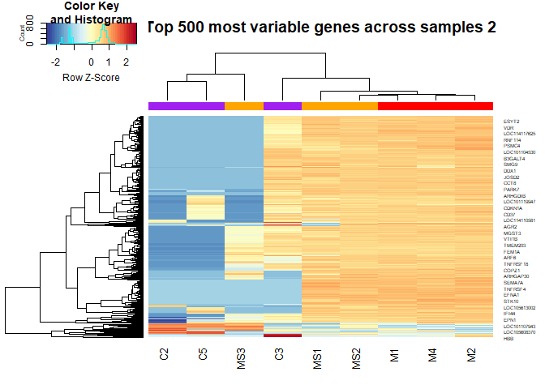

```r
mypalette=brewer.pal(11,"RdYlBu")
morecols=colorRampPalette(mypalette)
col.cell=c("purple","orange","red")[sampleinfo$group]
heatmap.2(highly_variable_lcpm,col=rev(morecols(50)),trace="none", main="Top 500 most variable genes across samples 2",ColSideColors=col.cell,scale="row")
```

## 2.3 Normalización

Una vez realizado el control de calidad de los datos el siguiente paso es la normalización, también denominada TMM, que se utiliza para eliminar sesgos de composición. Mediante la normalización se crea un conjunto de factores que junto con los tamaños de la biblioteca sirven para definir el tamaño efectivo de la biblioteca.

```r
y1=calcNormFactors(y1)
y1$samples
```

```
    group lib.size norm.factors
C2      1   948137    2.7722547
C3      1  9801400    0.7103768
C5      1  1674881    1.5566389
M1      1 18634924    0.7913125
M2      1 19230896    0.7913445
M4      1 17596225    0.7207764
MS1     1  8443455    0.8762772
MS2     1 11473509    0.7948465
MS3     1  2267329    1.0376510
```

```r
y2=calcNormFactors(y2)
y2$samples
```

```
    group lib.size norm.factors
C2      1   907390    2.8149337
C3      1  9253200    0.7170111
C5      1  1587350    1.5752817
M1      1 17780528    0.7896487
M2      1 18774995    0.7861537
M4      1 17233880    0.7152299
MS1     1  8319181    0.8716056
MS2     1 11145077    0.7906534
MS3     1  2197458    1.0279086
```

Cuando el valor del factor de normalización sale menor de 1 significa que el tamaño de la biblioteca va a disminuir y cuando sale mayor que 1 el tamaño de la bilioteca aumentará. Por lo tanto en tres de las muestras el tamaño va a aumentar y en seis va a disminuir.

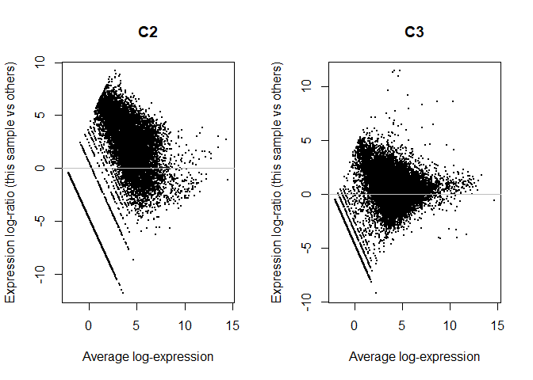

```r
par(mfrow=c(1,2))
plotMD(logcounts1,column = 1)
abline(h=0,col="grey")
plotMD(logcounts1,column = 2)
abline(h=0,col="grey")
```

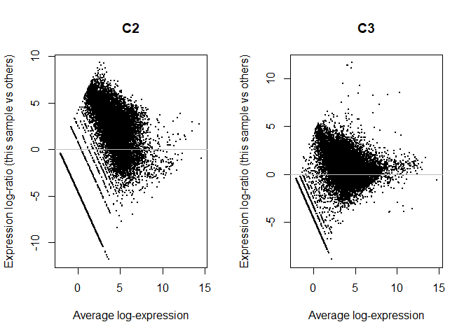

```r
par(mfrow=c(1,2))
plotMD(logcounts2,column = 1)
abline(h=0,col="grey")
plotMD(logcounts2,column = 2)
abline(h=0,col="grey")
```

## 2.4 Identificación de genes diferencialmente expresados

Para poder identificar los genes que se encuentran diferencialmente expresados en este ensayo vamos autilizar el paquete *limma*. Inicialmente tenemos que crear una matriz de diseño para los grupos a comparar.

```r
group=paste(sampleinfo$group,sep=".")
group=factor(group)
design=model.matrix(~ 0 + group)
design
```

```
  groupC groupMS groupMV
1      1       0       0
2      1       0       0
3      1       0       0
4      0       0       1
5      0       0       1
6      0       0       1
7      0       1       0
8      0       1       0
9      0       1       0
attr(,"assign")
[1] 1 1 1
attr(,"contrasts")
attr(,"contrasts")$group
[1] "contr.treatment"
```

```r
colnames(design)=levels(group)
design
```

```
  C MS MV
1 1  0  0
2 1  0  0
3 1  0  0
4 0  0  1
5 0  0  1
6 0  0  1
7 0  1  0
8 0  1  0
9 0  1  0
attr(,"assign")
[1] 1 1 1
attr(,"contrasts")
attr(,"contrasts")$group
[1] "contr.treatment"
```

Una vez que hemos crado la matriz de diseño vamos a realizar el estudio de estimación de tendencias de varianzas con respecto a la media del counting data con *voom*. La transformación que hace *voom* va a producir el objeto *Elist*.

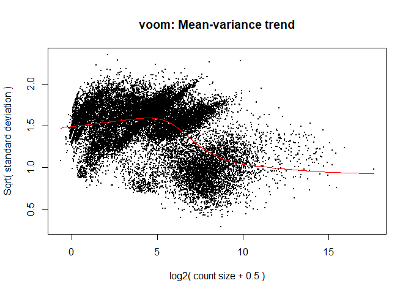

```r
par(mfrow=c(1,1))
v1=voom(y1,design,plot = TRUE)
```

```r
v1
```

```
An object of class "EList"
$targets
    group lib.size norm.factors
C2      1  2628477    2.7722547
C3      1  6962687    0.7103768
C5      1  2607185    1.5566389
M1      1 14746048    0.7913125
M2      1 15218264    0.7913445
M4      1 12682943    0.7207764
MS1     1  7398807    0.8762772
MS2     1  9119678    0.7948465
MS3     1  2352696    1.0376510

$E
                    C2        C3         C5        M1         M2         M4
LOC114112203 -2.394228 -3.799644 -0.7975309 -2.560329  0.4985327 -0.1412558
LOC114110836 -2.394228 -3.799644  3.2322164 -0.975366 -4.9277320  1.8743410
LOC114113923 -2.394228  5.247480 -2.3824934 -1.712332  3.3437310  3.4900003
LOC114112459 -2.394228  2.504136 -2.3824934 -4.882257  0.8536277 -4.6648178
PDCD1         2.249628 -3.799644 -2.3824934  5.362107  5.0820966  5.8907300
                     MS1        MS2       MS3
LOC114112203 -3.88729285  0.9402999  4.069465
LOC114110836 -2.30233035 -4.1889831  3.191949
LOC114113923 -3.88729285  3.1597451 -2.234316
LOC114112459  0.01959775 -1.3816282 -2.234316
PDCD1         4.85079941  5.5874499  4.731469
19981 more rows ...

$weights
          [,1]      [,2]      [,3]      [,4]      [,5]      [,6]      [,7]
[1,] 0.2117708 0.1960917 0.2117708 0.1646394 0.1641357 0.1670699 0.1633854
[2,] 0.1969153 0.1790559 0.1970712 0.1712165 0.1707469 0.1733938 0.1793555
[3,] 0.1822359 0.1667760 0.1823811 0.1734947 0.1753169 0.1659617 0.1780240
[4,] 0.1938910 0.1763841 0.1940443 0.1893905 0.1888075 0.1921959 0.1805517
[5,] 0.2012785 0.1830086 0.2014394 0.7625828 0.7698580 0.7245361 0.4921153
          [,8]      [,9]
[1,] 0.1602769 0.1815290
[2,] 0.1758600 0.2005795
[3,] 0.1746254 0.1990550
[4,] 0.1769719 0.2019355
[5,] 0.5527980 0.2204128
19981 more rows ...

$design
  C MS MV
1 1  0  0
2 1  0  0
3 1  0  0
4 0  0  1
5 0  0  1
6 0  0  1
7 0  1  0
8 0  1  0
9 0  1  0
attr(,"assign")
[1] 1 1 1
attr(,"contrasts")
attr(,"contrasts")$group
[1] "contr.treatment"
```

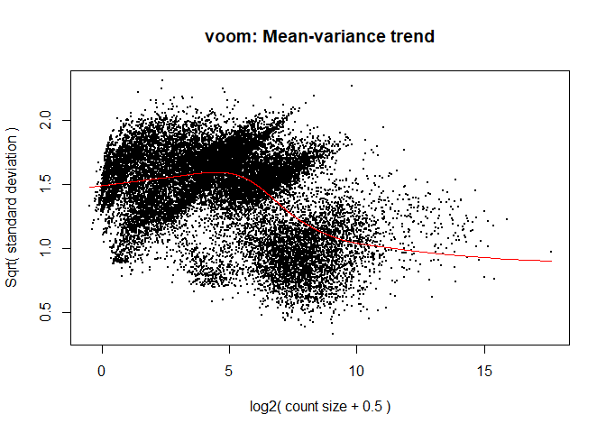

```r
par(mfrow=c(1,1))
v2=voom(y2,design,plot = TRUE)
```

```r
v2
```

```
An object of class "EList"
$targets
    group lib.size norm.factors
C2      1  2554243    2.8149337
C3      1  6634647    0.7170111
C5      1  2500523    1.5752817
M1      1 14040371    0.7896487
M2      1 14760032    0.7861537
M4      1 12326187    0.7152299
MS1     1  7251045    0.8716056
MS2     1  8811893    0.7906534
MS3     1  2258786    1.0279086

$E
                    C2        C3        C5         M1         M2         M4
LOC114112203 -2.352896 -3.730020 -2.322231 -2.4895811 -0.9767334  0.3305415
LOC114110836 -2.352896 -3.730020 -2.322231 -0.5635817 -4.8836240  1.4848697
LOC114113923 -2.352896  4.434887 -2.322231 -4.8115092  3.1220005  3.6755533
LOC114112459 -2.352896  2.378504 -2.322231 -4.8115092  1.2661231 -4.6236548
PDCD1        -2.352896 -3.730020 -2.322231  5.4587861  5.1621356  6.2036879
                   MS1       MS2       MS3
LOC114112203 -2.273227  1.286813  4.363611
LOC114110836 -3.858189 -4.139452  2.868846
LOC114113923  2.331635  3.422790 -2.175548
LOC114112459  2.551202 -4.139452 -2.175548
PDCD1         4.661447  5.593563  5.119073
20041 more rows ...

$weights
          [,1]      [,2]      [,3]      [,4]      [,5]      [,6]      [,7]
[1,] 0.2103051 0.2040662 0.2103051 0.1695451 0.1687195 0.1716275 0.1566320
[2,] 0.2103051 0.2040662 0.2103051 0.1725522 0.1718000 0.1744564 0.1880734
[3,] 0.1864958 0.1708371 0.1868837 0.1547497 0.1547535 0.1550312 0.1561900
[4,] 0.1952896 0.1780321 0.1956888 0.1888401 0.1879200 0.1912451 0.1823504
[5,] 0.2103051 0.2040662 0.2103051 0.7761152 0.7875270 0.7435598 0.4964340
          [,8]      [,9]
[1,] 0.1551040 0.1744718
[2,] 0.1845144 0.2103051
[3,] 0.1548653 0.1738226
[4,] 0.1789567 0.2041675
[5,] 0.5518429 0.2216109
20041 more rows ...

$design
  C MS MV
1 1  0  0
2 1  0  0
3 1  0  0
4 0  0  1
5 0  0  1
6 0  0  1
7 0  1  0
8 0  1  0
9 0  1  0
attr(,"assign")
[1] 1 1 1
attr(,"contrasts")
attr(,"contrasts")$group
[1] "contr.treatment"
```

Tras usar esta herramienta podemos comparar mediante un boxplot los resultados antes y después de sufrir este proceso:

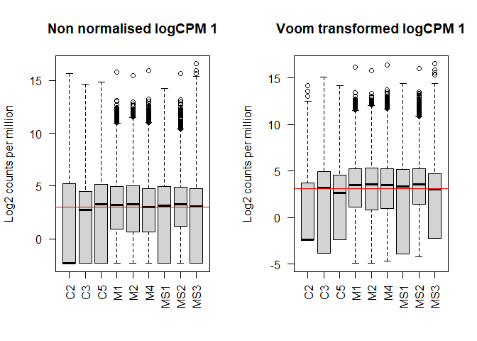

```r
par(mfrow=c(1,2))
boxplot(logcounts1, xlab="", ylab="Log2 counts per million",las=2,main="Non normalised logCPM 1")
abline(h=median(logcounts1),col="red")
boxplot(v1$E, xlab="", ylab="Log2 counts per million",las=2,main="Voom transformed logCPM 1")
abline(h=median(v1$E),col="red")
```

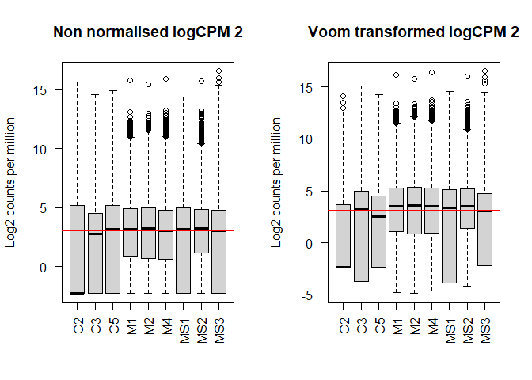

```r
par(mfrow=c(1,2))
boxplot(logcounts2, xlab="", ylab="Log2 counts per million",las=2,main="Non normalised logCPM 2")
abline(h=median(logcounts2),col="red")
boxplot(v2$E, xlab="", ylab="Log2 counts per million",las=2,main="Voom transformed logCPM 2")
abline(h=median(v2$E),col="red")
```

Vemos que gracias a *voom* ha aumentado la similitud entre los datos al compararlos con la situación antes de normalizar pero siguen existiendo diferencias entre ellos.

Al haber obtenido los datos de la función *voom* podemos utilizar *limma* para obtener la expresión diferencial de los genes. Hay que empezar por el ajuste del modelo lineal de cada gen usando la función mostrada a continuación.

```r
fit1=lmFit(v1)
names(fit1)
```

```
 [1] "coefficients"     "stdev.unscaled"   "sigma"            "df.residual"
 [5] "cov.coefficients" "pivot"            "rank"             "Amean"
 [9] "method"           "design"
```

```r
fit2=lmFit(v2)
names(fit2)
```

```
 [1] "coefficients"     "stdev.unscaled"   "sigma"            "df.residual"
 [5] "cov.coefficients" "pivot"            "rank"             "Amean"
 [9] "method"           "design"
```

Para poder obtener las expresiones diferenciales tenemos que concretar entre qué grupos queremos que se hagan, por lo tanto hay que usar *makeContrasts* para especificarlo.

```r
cont.matrix1=makeContrasts(CvsMV=C - MV, CvsMS=C - MS, MVvsMS=MV - MS,levels=design)
cont.matrix1
```

```
      Contrasts
Levels CvsMV CvsMS MVvsMS
    C      1     1      0
    MS     0    -1     -1
    MV    -1     0      1
```

```r
fit.cont1=contrasts.fit(fit1, cont.matrix1)
fit.cont1=eBayes(fit.cont1)
summa.fit1=decideTests(fit.cont1)
summary(summa.fit1)
```

```
       CvsMV CvsMS MVvsMS
Down    2735   364      0
NotSig 17037 19608  19986
Up       214    14      0
```

```r
topTable(fit.cont1,coef="CvsMV", sort.by="p")
```

```
                  logFC  AveExpr         t      P.Value   adj.P.Val        B
BCL2A1        -9.811790 3.008619 -9.820968 4.175713e-07 0.001380382 5.041909
ATG2A         -9.279711 3.250330 -9.785160 4.343882e-07 0.001380382 5.000410
IDO1          -8.958349 2.264803 -9.445878 6.351300e-07 0.001380382 4.766332
LOC101120392 -11.351884 3.975926 -9.443830 6.366081e-07 0.001380382 4.840374
LGI3          -9.298745 3.041717 -9.402225 6.674610e-07 0.001380382 4.751545
SLAMF8        -8.862820 2.593914 -9.344092 7.132852e-07 0.001380382 4.692596
LOC101119685 -10.487782 4.735460 -9.197036 8.449616e-07 0.001380382 4.621357
CDKN1B        -8.577015 2.605357 -8.978928 1.090542e-06 0.001380382 4.421468
MARCKSL1      -9.082052 2.968771 -8.954290 1.122762e-06 0.001380382 4.430557
ORAI1         -8.335136 2.458675 -8.863797 1.250148e-06 0.001380382 4.319697
```

```r
topTable(fit.cont1,coef="CvsMS", sort.by="p")
```

```
                 logFC  AveExpr         t      P.Value   adj.P.Val        B
ATG2A        -9.161156 3.250330 -9.301582 7.489253e-07 0.007861758 4.530268
KCNC3        -8.728494 2.790257 -9.076830 9.719708e-07 0.007861758 4.329301
IL33         -8.592118 2.581131 -8.470355 2.014378e-06 0.007861758 3.873396
CASC3        -8.500598 2.815434 -8.193311 2.846570e-06 0.007861758 3.628902
MARCKSL1     -8.698768 2.968771 -8.040358 3.457892e-06 0.007861758 3.511405
LGI3         -8.487781 3.041717 -8.027922 3.513426e-06 0.007861758 3.501798
LOC101102085 -8.427907 2.726678 -8.026277 3.520847e-06 0.007861758 3.478787
LOC101119685 -9.380641 4.735460 -8.017636 3.560082e-06 0.007861758 3.630540
CTNS         -8.066305 2.508868 -7.838241 4.489792e-06 0.007861758 3.257899
SYNE3        -7.778401 2.188951 -7.689028 5.461021e-06 0.007861758 3.108844
```

```r
topTable(fit.cont1,coef="MVvsMS", sort.by="p")
```

```
                 logFC    AveExpr         t      P.Value adj.P.Val         B
LOC121819721 -7.072180 -1.8094421 -5.681432 0.0001001643 0.7842921 -4.580250
KCNU1        -7.385757 -1.6698818 -5.411778 0.0001543561 0.7842921 -4.580260
LOC121816079  5.891822 -1.2800788  4.721325 0.0004892197 0.7842921 -4.579924
GPR137C      -6.801129 -1.9066458 -4.636078 0.0005666443 0.7842921 -4.582370
BRINP1       -6.253084 -1.5643166 -4.433939 0.0008058219 0.7842921 -4.582903
HAO1         -7.375871 -0.2399018 -4.375669 0.0008927662 0.7842921 -4.582570
LOC114111036 -6.559526  1.1286306 -4.366285 0.0009076549 0.7842921 -4.581696
SH2D4B       -7.015599  0.2214885 -4.342705 0.0009462186 0.7842921 -4.581459
LOC105613401  5.499026 -1.4002249  4.339981 0.0009507816 0.7842921 -4.581937
LOC121820217  5.380849 -1.4459712  4.290680 0.0010374385 0.7842921 -4.582368
```

Vemos que según los análisis que hemos llevado a cabo si comparamos el grupo de animales control frente a los que tienen Maedi-Visna tenemos 2735 genes con una expresión diferencial menor y 214 genes que se encuentran sobreexpresados; al comparar las muestras control con las infectadas con Maedi-Visna y *scrapie* hay 364 genes con una expresión menor y 14 sobreexpresados y al comparar los dos grupos con maedi-Visna no hay diferencias de expresión.

Repetimos el proceso para el sentido de lectura 2:

```r
cont.matrix2=makeContrasts(CvsMV=C - MV, CvsMS=C - MS, MVvsMS=MV - MS,levels=design)
cont.matrix2
```

```
      Contrasts
Levels CvsMV CvsMS MVvsMS
    C      1     1      0
    MS     0    -1     -1
    MV    -1     0      1
```

```r
fit.cont2=contrasts.fit(fit2, cont.matrix2)
fit.cont2=eBayes(fit.cont2)
summa.fit2=decideTests(fit.cont2)
summary(summa.fit2)
```

```
       CvsMV CvsMS MVvsMS
Down    2736   368      0
NotSig 17104 19662  20046
Up       206    16      0
```

```r
topTable(fit.cont2,coef="CvsMV", sort.by="p")
```

```
                  logFC  AveExpr         t      P.Value   adj.P.Val        B
BCL2A1        -9.715717 3.025027 -9.727171 4.240749e-07 0.001465936 5.032801
LOC101119685 -10.502554 4.736071 -9.552774 5.162756e-07 0.001465936 4.943602
IDO1          -8.922850 2.295739 -9.526779 5.317669e-07 0.001465936 4.866257
SMIM29        -8.834499 2.750744 -9.159105 8.134070e-07 0.001465936 4.610356
LOC101120392 -11.302704 3.897557 -9.135665 8.361191e-07 0.001465936 4.682926
ARHGAP30      -9.726313 3.273458 -9.091521 8.807577e-07 0.001465936 4.600872
SLAMF8        -8.690476 2.498333 -9.056920 9.175293e-07 0.001465936 4.528817
CASC3         -8.764673 2.871640 -9.040280 9.357966e-07 0.001465936 4.521746
ATG2A         -9.209265 3.081243 -8.903234 1.101917e-06 0.001465936 4.444745
LOC101120093 -10.601284 3.613916 -8.888407 1.121700e-06 0.001465936 4.480939
```

```r
topTable(fit.cont2,coef="CvsMS", sort.by="p")
```

```
                 logFC  AveExpr         t      P.Value   adj.P.Val        B
IL33         -8.544830 2.600015 -8.449506 1.919134e-06 0.006469515 3.878264
LOC101119685 -9.532240 4.736071 -8.437291 1.948601e-06 0.006469515 4.025001
CASC3        -8.405736 2.871640 -8.100696 2.984514e-06 0.006469515 3.565054
LOC101102085 -8.417692 2.759370 -7.971223 3.528244e-06 0.006469515 3.454208
ATG2A        -8.781264 3.081243 -7.960497 3.577813e-06 0.006469515 3.484937
LTB          -9.630628 3.604970 -7.927900 3.733069e-06 0.006469515 3.570948
RAB35        -7.970324 2.558112 -7.814616 4.331065e-06 0.006469515 3.278886
ARHGAP30     -8.861299 3.273458 -7.747463 4.733189e-06 0.006469515 3.317143
GLB1         -8.449905 2.795791 -7.645591 5.421133e-06 0.006469515 3.164312
KAT2B        -7.830344 2.572367 -7.630796 5.529608e-06 0.006469515 3.098148
```

```r
topTable(fit.cont2,coef="MVvsMS", sort.by="p")
```

```
                 logFC    AveExpr         t      P.Value adj.P.Val         B
LOC121819721 -6.732671 -1.8749850 -5.306177 0.0001768450 0.7885556 -4.581105
LOC121819062 -7.595475 -1.1758780 -4.981081 0.0003045997 0.7885556 -4.580712
LOC114111036 -6.703286  1.3627319 -4.699463 0.0004935790 0.7885556 -4.580875
LOC114117086 -7.041731 -1.1941282 -4.480655 0.0007233650 0.7885556 -4.582683
LOC101111220  5.515246 -1.3578708  4.399932 0.0008341824 0.7885556 -4.581870
LOC105613401  5.544407 -1.3378987  4.358817 0.0008972713 0.7885556 -4.581845
RRAGA         5.408980 -0.3760044  4.316031 0.0009682037 0.7885556 -4.578475
KCNU1        -6.286387 -1.2940858 -4.313176 0.0009731384 0.7885556 -4.583018
LOC121816079  5.321884 -0.9084282  4.265556 0.0010594216 0.7885556 -4.580915
LOC114109432 -6.390394  1.2343823 -4.238944 0.0011110557 0.7885556 -4.582663
```

Los resultados que visualizamos son muy similares a los obtenidos en el sentido de lectura 1. Los dos grupos infectados con MV no presentan diferencias significativas de expresión, al comparar el grupo control con el grupo con MV hay 2736 genes con un descenso en su expresión y 206 genes sobreexpresados; por último si comparamos el grupo control con el grupo con MV y *scrapie* hay 368 genes con una menor expresión y 16 sobreexpresados.

## 2.5 Anotación de los resultados

Para poder extraer más información de la lista de genes obtenida anteriormente vamos a crear un nuevo data.frame con nueva información como puede ser el nombre completo del gen o su símbolo. Vamos a tener que utilizar el paquete *AnnotationHub* que contiene un objeto *OrgDb* preconfigurado con la información genética de la oveja basada en NCBI Gene IDs.

```r
ah=AnnotationHub()
```

```
using temporary cache C:\Users\delfi\AppData\Local\Temp\RtmpYBqJtp/BiocFileCache
```

```
snapshotDate(): 2020-10-27
```

```r
query(ah, c("Ovis aries", "OrgDb"))
```

```
AnnotationHub with 1 record
# snapshotDate(): 2020-10-27
# names(): AH85595
# $dataprovider: ftp://ftp.ncbi.nlm.nih.gov/gene/DATA/
# $species: Ovis aries
# $rdataclass: OrgDb
# $rdatadateadded: 2020-10-27
# $title: org.Ovis_aries.eg.sqlite
# $description: NCBI gene ID based annotations about Ovis aries
# $taxonomyid: 9940
# $genome: NCBI genomes
# $sourcetype: NCBI/UniProt
# $sourceurl: ftp://ftp.ncbi.nlm.nih.gov/gene/DATA/, ftp://ftp.uniprot.org/p...
# $sourcesize: NA
# $tags: c("NCBI", "Gene", "Annotation")
# retrieve record with 'object[["AH85595"]]'
```

Una vez que sabemos cómo se llama el objeto con la información relativa a la anotación de la oveja creamos la base de datos que va a recoger esa información y la llamamos *org.Oa.eg.db*.

```r
org.Oa.eg.db=ah[["AH85595"]]
```

Para poder saber exactamente qué información de anotación del genoma tenemos y de qué identificadores disponemos vamos a visualizar las columnas y palabras claves de la base de datos que acabamos de crear.

```r
columns(org.Oa.eg.db)
```

```
 [1] "ACCNUM"      "ALIAS"       "CHR"         "ENSEMBL"     "ENTREZID"
 [6] "EVIDENCE"    "EVIDENCEALL" "GENENAME"    "GID"         "GO"
[11] "GOALL"       "ONTOLOGY"    "ONTOLOGYALL" "PMID"        "REFSEQ"
[16] "SYMBOL"      "UNIGENE"
```

```r
keytypes(org.Oa.eg.db)
```

```
 [1] "ACCNUM"      "ALIAS"       "ENSEMBL"     "ENTREZID"    "EVIDENCE"
 [6] "EVIDENCEALL" "GENENAME"    "GID"         "GO"          "GOALL"
[11] "ONTOLOGY"    "ONTOLOGYALL" "PMID"        "REFSEQ"      "SYMBOL"
[16] "UNIGENE"
```

A continuación vamos a crear un data.frame que va a contener información como puede ser el nombre completo del gen, su símbolo o su código de gene ontology (GO):

```r
ann1=select(org.Oa.eg.db, keys=rownames(fit.cont1), columns=c("ENTREZID","SYMBOL","GO","GENENAME","ACCNUM"), keytype="SYMBOL")
head(ann1)
```

```
        SYMBOL  ENTREZID   GO
1 LOC114112203 114112203 <NA>
2 LOC114112203 114112203 <NA>
3 LOC114110836 114110836 <NA>
4 LOC114113923 114113923 <NA>
5 LOC114112459 114112459 <NA>
6        PDCD1 101121636 <NA>
                                                 GENENAME         ACCNUM
1 ubiquitin carboxyl-terminal hydrolase 17-like protein 6 XP_027819548.1
2 ubiquitin carboxyl-terminal hydrolase 17-like protein 6 XM_027963747.1
3 ubiquitin carboxyl-terminal hydrolase 17-like protein 6           <NA>
4                            uncharacterized LOC114113923 XR_003588699.1
5                            uncharacterized LOC114112459 XR_003587854.1
6                                 programmed cell death 1 XP_027819970.1
```

```r
fit.cont1$genes=ann1
topTable(fit.cont1,coef="CvsMV",sort.by="p")
```

```
                   SYMBOL  ENTREZID         GO
BCL2A1             ARL13B 101123516       <NA>
ATG2A               GSK3B 100169938 GO:1901215
IDO1                 DLG1 101103028 GO:0097016
LOC101120392 LOC114111025 114111025       <NA>
LGI3                 ERI3 101116000       <NA>
SLAMF8             PABPC4 101118742 GO:0005829
LOC101119685        GSK3B 100169938 GO:0001954
CDKN1B               NEXN 101122738 GO:0005886
MARCKSL1           ZFYVE9 101114400       <NA>
ORAI1               USP16 101109404 GO:0004843
                                            GENENAME         ACCNUM      logFC
BCL2A1       ADP ribosylation factor like GTPase 13B XM_027979029.1  -9.811790
ATG2A                glycogen synthase kinase 3 beta XP_012034491.1  -9.279711
IDO1            discs large MAGUK scaffold protein 1 XP_027812877.1  -8.958349
LOC101120392                     U6 spliceosomal RNA XR_003587151.1 -11.351884
LGI3            ERI1 exoribonuclease family member 3 XM_012121548.2  -9.298745
SLAMF8         poly(A) binding protein cytoplasmic 4 XM_012102245.3  -8.862820
LOC101119685         glycogen synthase kinase 3 beta GAAI01004891.1 -10.487782
CDKN1B               nexilin F-actin binding protein XP_027827222.1  -8.577015
MARCKSL1          zinc finger FYVE-type containing 9 XP_027825923.1  -9.082052
ORAI1                ubiquitin specific peptidase 16 XM_012186762.3  -8.335136
              AveExpr         t      P.Value   adj.P.Val        B
BCL2A1       3.008619 -9.820968 4.175713e-07 0.001380382 5.041909
ATG2A        3.250330 -9.785160 4.343882e-07 0.001380382 5.000410
IDO1         2.264803 -9.445878 6.351300e-07 0.001380382 4.766332
LOC101120392 3.975926 -9.443830 6.366081e-07 0.001380382 4.840374
LGI3         3.041717 -9.402225 6.674610e-07 0.001380382 4.751545
SLAMF8       2.593914 -9.344092 7.132852e-07 0.001380382 4.692596
LOC101119685 4.735460 -9.197036 8.449616e-07 0.001380382 4.621357
CDKN1B       2.605357 -8.978928 1.090542e-06 0.001380382 4.421468
MARCKSL1     2.968771 -8.954290 1.122762e-06 0.001380382 4.430557
ORAI1        2.458675 -8.863797 1.250148e-06 0.001380382 4.319697
```

```r
topTable(fit.cont1,coef="CvsMS",sort.by="p")
```

```
                   SYMBOL  ENTREZID         GO
ATG2A               GSK3B 100169938 GO:1901215
KCNC3             NECTIN4 101123428 GO:0007155
IL33                 TOE1 101119770 GO:0015030
CASC3               MRPL9 101119267 GO:0005762
MARCKSL1           ZFYVE9 101114400       <NA>
LGI3                 ERI3 101116000       <NA>
LOC101102085         DEDD 101106303       <NA>
LOC101119685        GSK3B 100169938 GO:0001954
CTNS               PRUNE1 101117814       <NA>
SYNE3        LOC101110467 101110467 GO:0016021
                                         GENENAME         ACCNUM     logFC
ATG2A             glycogen synthase kinase 3 beta XP_012034491.1 -9.161156
KCNC3             nectin cell adhesion molecule 4 XM_015092336.2 -8.728494
IL33                  target of EGR1, exonuclease XM_012125407.3 -8.592118
CASC3          mitochondrial ribosomal protein L9 XP_004002552.1 -8.500598
MARCKSL1       zinc finger FYVE-type containing 9 XP_027825923.1 -8.698768
LGI3         ERI1 exoribonuclease family member 3 XM_012121548.2 -8.487781
LOC101102085     death effector domain containing XP_027833148.1 -8.427907
LOC101119685      glycogen synthase kinase 3 beta GAAI01004891.1 -9.380641
CTNS                   prune exopolyphosphatase 1 XM_027974606.1 -8.066305
SYNE3                   transmembrane protein 45A XM_004002883.4 -7.778401
              AveExpr         t      P.Value   adj.P.Val        B
ATG2A        3.250330 -9.301582 7.489253e-07 0.007861758 4.530268
KCNC3        2.790257 -9.076830 9.719708e-07 0.007861758 4.329301
IL33         2.581131 -8.470355 2.014378e-06 0.007861758 3.873396
CASC3        2.815434 -8.193311 2.846570e-06 0.007861758 3.628902
MARCKSL1     2.968771 -8.040358 3.457892e-06 0.007861758 3.511405
LGI3         3.041717 -8.027922 3.513426e-06 0.007861758 3.501798
LOC101102085 2.726678 -8.026277 3.520847e-06 0.007861758 3.478787
LOC101119685 4.735460 -8.017636 3.560082e-06 0.007861758 3.630540
CTNS         2.508868 -7.838241 4.489792e-06 0.007861758 3.257899
SYNE3        2.188951 -7.689028 5.461021e-06 0.007861758 3.108844
```

```r
topTable(fit.cont1,coef="MVvsMS",sort.by="p")
```

```
             SYMBOL  ENTREZID         GO                             GENENAME
LOC121819721   NCDN 101115750       <NA>                        neurochondrin
KCNU1          DLG1 101103028 GO:0044325 discs large MAGUK scaffold protein 1
LOC121816079 TDRD10 101103865       <NA>           tudor domain containing 10
GPR137C      ADORA3    443330 GO:0005886                adenosine A3 receptor
BRINP1       ELOVL1 101110801 GO:0102336          ELOVL fatty acid elongase 1
HAO1           PKLR    780515       <NA>                  pyruvate kinase L/R
LOC114111036   AGO3 101111326 GO:0010501 argonaute RISC catalytic component 3
SH2D4B         DLG1 101103028 GO:0097025 discs large MAGUK scaffold protein 1
LOC105613401  SYT11 101120970 GO:1900424                     synaptotagmin 11
LOC121820217 NOTCH2 101112098 GO:0005654                     notch receptor 2
                     ACCNUM     logFC    AveExpr         t      P.Value
LOC121819721 XP_027823538.1 -7.072180 -1.8094421 -5.681432 0.0001001643
KCNU1        XP_011952013.1 -7.385757 -1.6698818 -5.411778 0.0001543561
LOC121816079 XM_027975692.1  5.891822 -1.2800788  4.721325 0.0004892197
GPR137C      NM_001009775.2 -6.801129 -1.9066458 -4.636078 0.0005666443
BRINP1       XM_004001877.4 -6.253084 -1.5643166 -4.433939 0.0008058219
HAO1             AFL02769.1 -7.375871 -0.2399018 -4.375669 0.0008927662
LOC114111036 XM_012097219.2 -6.559526  1.1286306 -4.366285 0.0009076549
SH2D4B       XP_011951982.1 -7.015599  0.2214885 -4.342705 0.0009462186
LOC105613401 XM_004002595.4  5.499026 -1.4002249  4.339981 0.0009507816
LOC121820217 XP_004002441.2  5.380849 -1.4459712  4.290680 0.0010374385
             adj.P.Val         B
LOC121819721 0.7842921 -4.580250
KCNU1        0.7842921 -4.580260
LOC121816079 0.7842921 -4.579924
GPR137C      0.7842921 -4.582370
BRINP1       0.7842921 -4.582903
HAO1         0.7842921 -4.582570
LOC114111036 0.7842921 -4.581696
SH2D4B       0.7842921 -4.581459
LOC105613401 0.7842921 -4.581937
LOC121820217 0.7842921 -4.582368
```

Si repetimos la creación de este data.frame con los datos del otro sentido de lectura obtenemos:

```r
ann2=select(org.Oa.eg.db, keys=rownames(fit.cont1), columns=c("ENTREZID","SYMBOL","GO","GENENAME","ACCNUM"), keytype="SYMBOL")
head(ann2)
```

```
        SYMBOL  ENTREZID   GO
1 LOC114112203 114112203 <NA>
2 LOC114112203 114112203 <NA>
3 LOC114110836 114110836 <NA>
4 LOC114113923 114113923 <NA>
5 LOC114112459 114112459 <NA>
6        PDCD1 101121636 <NA>
                                                 GENENAME         ACCNUM
1 ubiquitin carboxyl-terminal hydrolase 17-like protein 6 XP_027819548.1
2 ubiquitin carboxyl-terminal hydrolase 17-like protein 6 XM_027963747.1
3 ubiquitin carboxyl-terminal hydrolase 17-like protein 6           <NA>
4                            uncharacterized LOC114113923 XR_003588699.1
5                            uncharacterized LOC114112459 XR_003587854.1
6                                 programmed cell death 1 XP_027819970.1
```

```r
fit.cont2$genes=ann2
topTable(fit.cont2,coef="CvsMV",sort.by="p")
```

```
             SYMBOL  ENTREZID         GO
BCL2A1       CLDND1 101106127 GO:0016021
LOC101119685  GSK3B 100169938 GO:1901216
IDO1           DLG1 101103028 GO:0060090
SMIM29       PHLDB2 101118837 GO:0010717
LOC101120392    BOC 101123082       <NA>
ARHGAP30     PABPC4 101118742 GO:0003729
SLAMF8       PABPC4 101118742 GO:0005829
CASC3         TDRKH 101119519 GO:0071546
ATG2A         GSK3B 100169938 GO:0031175
LOC101120093  ANXA9 101109752 GO:0015464
                                                      GENENAME         ACCNUM
BCL2A1                             claudin domain containing 1 XM_004002866.3
LOC101119685                   glycogen synthase kinase 3 beta XM_027973494.1
IDO1                      discs large MAGUK scaffold protein 1 XM_027957046.1
SMIM29       pleckstrin homology like domain family B member 2 XM_027979915.1
LOC101120392  BOC cell adhesion associated, oncogene regulated XM_027979999.1
ARHGAP30                 poly(A) binding protein cytoplasmic 4 XM_004001828.4
SLAMF8                   poly(A) binding protein cytoplasmic 4 XM_027968325.1
CASC3                           tudor and KH domain containing XP_027830804.1
ATG2A                          glycogen synthase kinase 3 beta XP_027831102.1
LOC101120093                                        annexin A9 XP_012036236.1
                  logFC  AveExpr         t      P.Value   adj.P.Val        B
BCL2A1        -9.715717 3.025027 -9.727171 4.240749e-07 0.001465936 5.032801
LOC101119685 -10.502554 4.736071 -9.552774 5.162756e-07 0.001465936 4.943602
IDO1          -8.922850 2.295739 -9.526779 5.317669e-07 0.001465936 4.866257
SMIM29        -8.834499 2.750744 -9.159105 8.134070e-07 0.001465936 4.610356
LOC101120392 -11.302704 3.897557 -9.135665 8.361191e-07 0.001465936 4.682926
ARHGAP30      -9.726313 3.273458 -9.091521 8.807577e-07 0.001465936 4.600872
SLAMF8        -8.690476 2.498333 -9.056920 9.175293e-07 0.001465936 4.528817
CASC3         -8.764673 2.871640 -9.040280 9.357966e-07 0.001465936 4.521746
ATG2A         -9.209265 3.081243 -8.903234 1.101917e-06 0.001465936 4.444745
LOC101120093 -10.601284 3.613916 -8.888407 1.121700e-06 0.001465936 4.480939
```

```r
topTable(fit.cont2,coef="CvsMS",sort.by="p")
```

```
              SYMBOL  ENTREZID         GO
IL33            TOE1 101119770 GO:0017069
LOC101119685   GSK3B 100169938 GO:1901216
CASC3          TDRKH 101119519 GO:0071546
LOC101102085    PPOX 101103440 GO:0005743
ATG2A          GSK3B 100169938 GO:0031175
LTB          ZDHHC23 101102277 GO:0016021
RAB35        ADAMTS1 100415773 GO:1904707
ARHGAP30      PABPC4 101118742 GO:0003729
GLB1             BBX 101115417 GO:0005829
KAT2B         ELOVL1 101110801 GO:0005789
                                                             GENENAME
IL33                                      target of EGR1, exonuclease
LOC101119685                          glycogen synthase kinase 3 beta
CASC3                                  tudor and KH domain containing
LOC101102085                               protoporphyrinogen oxidase
ATG2A                                 glycogen synthase kinase 3 beta
LTB                     zinc finger DHHC-type palmitoyltransferase 23
RAB35        ADAM metallopeptidase with thrombospondin type 1 motif 1
ARHGAP30                        poly(A) binding protein cytoplasmic 4
GLB1                    BBX high mobility group box domain containing
KAT2B                                     ELOVL fatty acid elongase 1
                     ACCNUM     logFC  AveExpr         t      P.Value
IL33         XP_011980631.1 -8.544830 2.600015 -8.449506 1.919134e-06
LOC101119685 XM_027973494.1 -9.532240 4.736071 -8.437291 1.948601e-06
CASC3        XP_027830804.1 -8.405736 2.871640 -8.100696 2.984514e-06
LOC101102085 XM_027977359.1 -8.417692 2.759370 -7.971223 3.528244e-06
ATG2A        XP_027831102.1 -8.781264 3.081243 -7.960497 3.577813e-06
LTB          XM_004002929.4 -9.630628 3.604970 -7.927900 3.733069e-06
RAB35        XM_004002797.4 -7.970324 2.558112 -7.814616 4.331065e-06
ARHGAP30     XM_004001828.4 -8.861299 3.273458 -7.747463 4.733189e-06
GLB1         XM_012189597.3 -8.449905 2.795791 -7.645591 5.421133e-06
KAT2B        XP_011973186.1 -7.830344 2.572367 -7.630796 5.529608e-06
               adj.P.Val        B
IL33         0.006469515 3.878264
LOC101119685 0.006469515 4.025001
CASC3        0.006469515 3.565054
LOC101102085 0.006469515 3.454208
ATG2A        0.006469515 3.484937
LTB          0.006469515 3.570948
RAB35        0.006469515 3.278886
ARHGAP30     0.006469515 3.317143
GLB1         0.006469515 3.164312
KAT2B        0.006469515 3.098148
```

```r
topTable(fit.cont2,coef="MVvsMS",sort.by="p")
```

```
             SYMBOL  ENTREZID         GO
LOC121819721   NCDN 101115750       <NA>
LOC121819062   FGGY 101104022 GO:0019321
LOC114111036   AGO3 101111326 GO:0010501
LOC114117086  TDRKH 101119519 GO:0007140
LOC101111220   DDR2 101109754       <NA>
LOC105613401   RIT1 100145877 GO:0007165
RRAGA        MMACHC 101120707 GO:0031419
KCNU1          DLG1 101103028 GO:0031434
LOC121816079  KCNN3 101112614 GO:0016021
LOC114109432  DZIP3 101116191 GO:0031593
                                                             GENENAME
LOC121819721                                            neurochondrin
LOC121819062               FGGY carbohydrate kinase domain containing
LOC114111036                     argonaute RISC catalytic component 3
LOC114117086                           tudor and KH domain containing
LOC101111220              discoidin domain receptor tyrosine kinase 2
LOC105613401                                  Ras like without CAAX 1
RRAGA                            metabolism of cobalamin associated C
KCNU1                            discs large MAGUK scaffold protein 1
LOC121816079 potassium calcium-activated channel subfamily N member 3
LOC114109432                    DAZ interacting zinc finger protein 3
                     ACCNUM     logFC    AveExpr         t      P.Value
LOC121819721 XP_027823522.1 -6.732671 -1.8749850 -5.306177 0.0001768450
LOC121819062 XM_012158100.3 -7.595475 -1.1758780 -4.981081 0.0003045997
LOC114111036 XM_027967800.1 -6.703286  1.3627319 -4.699463 0.0004935790
LOC114117086 XM_012181277.3 -7.041731 -1.1941282 -4.480655 0.0007233650
LOC101111220 XM_004002713.3  5.515246 -1.3578708  4.399932 0.0008341824
LOC105613401 NM_001126361.1  5.544407 -1.3378987  4.358817 0.0008972713
RRAGA        XM_004001917.4  5.408980 -0.3760044  4.316031 0.0009682037
KCNU1        XP_027812877.1 -6.286387 -1.2940858 -4.313176 0.0009731384
LOC121816079 XM_027975769.1  5.321884 -0.9084282  4.265556 0.0010594216
LOC114109432 XP_012045256.2 -6.390394  1.2343823 -4.238944 0.0011110557
             adj.P.Val         B
LOC121819721 0.7885556 -4.581105
LOC121819062 0.7885556 -4.580712
LOC114111036 0.7885556 -4.580875
LOC114117086 0.7885556 -4.582683
LOC101111220 0.7885556 -4.581870
LOC105613401 0.7885556 -4.581845
RRAGA        0.7885556 -4.578475
KCNU1        0.7885556 -4.583018
LOC121816079 0.7885556 -4.580915
LOC114109432 0.7885556 -4.582663
```

Ahora vamos a crear un volcano plot en el que veamos los genes con expresiones más diferenciales. Empezamos creando los del sentido de lectura 1 para cada una de las comparaciones entre grupos:

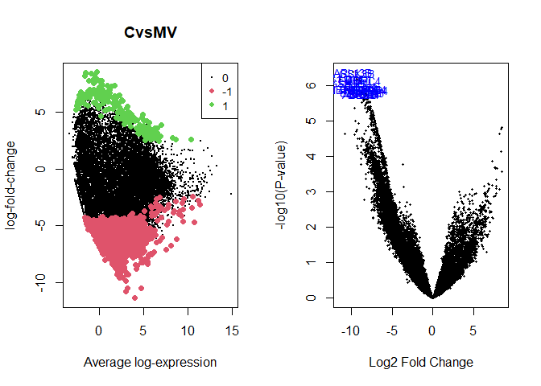

```r
par(mfrow=c(1,2))
plotMD(fit.cont1,coef=1,status=summa.fit1[,"CvsMV"], values = c(-1, 1))
volcanoplot(fit.cont1,coef=1,highlight=20,names=fit.cont1$genes$SYMBOL)
```

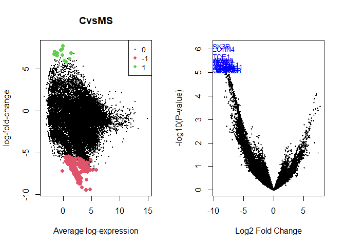

```r
par(mfrow=c(1,2))
plotMD(fit.cont1,coef=2,status=summa.fit1[,"CvsMS"], values = c(-1, 1))
volcanoplot(fit.cont1,coef=2,highlight=20,names=fit.cont1$genes$SYMBOL)
```

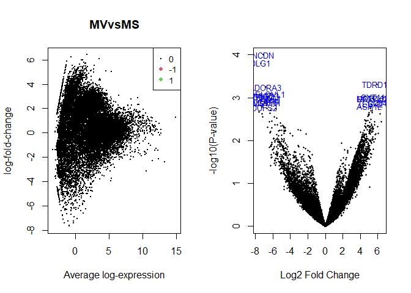

```r
par(mfrow=c(1,2))
plotMD(fit.cont1,coef=3,status=summa.fit1[,"MVvsMS"], values = c(-1, 1))
volcanoplot(fit.cont1,coef=3,highlight=20,names=fit.cont1$genes$SYMBOL)
```

Finalmente repetimos la creación de estos volcano plot pero para los datos analizados correspondientes al otro sentido de lectura:

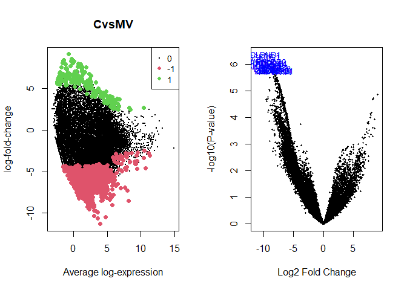

```r
par(mfrow=c(1,2))
plotMD(fit.cont2,coef=1,status=summa.fit2[,"CvsMV"], values = c(-1, 1))
volcanoplot(fit.cont2,coef=1,highlight=20,names=fit.cont2$genes$SYMBOL)
```

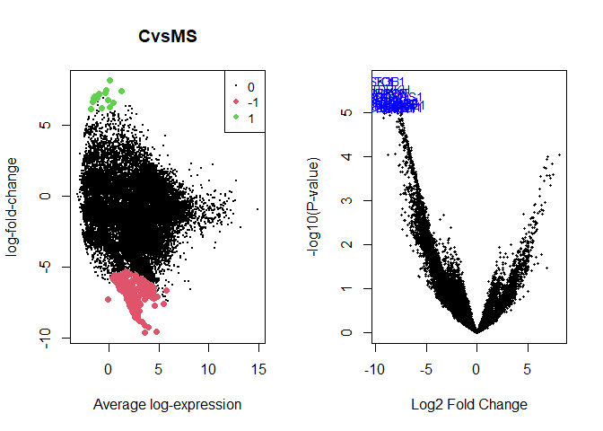

```r
par(mfrow=c(1,2))
plotMD(fit.cont2,coef=2,status=summa.fit2[,"CvsMS"], values = c(-1, 1))
volcanoplot(fit.cont2,coef=2,highlight=20,names=fit.cont2$genes$SYMBOL)
```

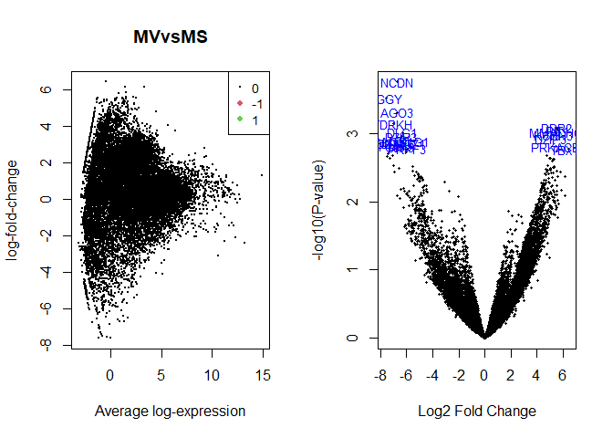

```r
par(mfrow=c(1,2))
plotMD(fit.cont2,coef=3,status=summa.fit2[,"MVvsMS"], values = c(-1, 1))
volcanoplot(fit.cont2,coef=3,highlight=20,names=fit.cont2$genes$SYMBOL)
```

## 2.6 Análisis de significación biológica

El siguiente paso en nuestro análisis es realizar un análisis de significación biológica, lo vamos a hacer con la herramienta web *Enrichr* por lo que necesitamos exportar los resultados que hemos obtenido. Vamos a exportarlos a archivos csv teniendo en cuenta el p valor y ordenándolos en relación a *loFC* para diferenciar los genes sobreexpresados y los que tienen una menor expresión génica.

```r
# Seleccionamos la información referente a la comparación CvsMV del primer sentido de lectura
res.coef1_1=topTable(fit.cont1, coef=1, number=2949, sort.by="p", resort.by="logFC")
res.coef1_1DF=as.data.frame(res.coef1_1)
write.csv(res.coef1_1DF, file = "fit.cont1_1.csv")

# Seleccionamos la información referente a la comparación CvsMS del primer sentido de lectura
res.coef1_2=topTable(fit.cont1, coef=2, number=378, sort.by="p", resort.by="logFC")
res.coef1_2DF=as.data.frame(res.coef1_2)
write.csv(res.coef1_2DF, file = "fit.cont1_2.csv")

# Seleccionamos la información referente a la comparación CvsMV del segundo sentido de lectura
res.coef2_1=topTable(fit.cont2, coef=1, number=2942, sort.by="p", resort.by="logFC")
res.coef2_1DF=as.data.frame(res.coef2_1)
write.csv(res.coef2_1DF, file = "fit.cont2_1.csv")

# Seleccionamos la información referente a la comparación CvsMS del segundo sentido de lectura
res.coef2_2=topTable(fit.cont2, coef=2, number=384, sort.by="p", resort.by="logFC")
res.coef2_2DF=as.data.frame(res.coef2_2)
write.csv(res.coef2_2DF, file = "fit.cont2_2.csv")
```